# Phonetic analysis

Segments, prosody and acoustic measurement

Dr Massimiliano Canzi

# The Prinzivalli case

`Did you know:` koalas have fingerprints, and under a microscope they look remarkably like ours. The anthropologist who described them in the 1990s added that koala prints turning up at a crime scene was extremely unlikely.

*Source: Henneberg, Lambert & Leigh (1997), Natural Science*

## Bomb threats against an airline

- In 1983, a caller made a series of bomb threats by telephone to Pan American Airlines, and some calls were recorded
- The police charged a suspect, Paul Prinzivalli
- His defence sent the threat calls, and a recording of Prinzivalli, to the sociolinguist William Labov

Labov showed, by listening and by acoustic analysis, that the caller and the suspect had different accents.

## Two vowels

- The caller had a Boston accent: he used almost the same vowel in *bomb* and *off*
- Prinzivalli had a New York accent, which keeps the two vowels apart
- Prinzivalli was acquitted; the judge named the phonetic evidence as crucial for reasonable doubt

One of the earliest documented cases of expert speaker comparison (Labov, 1988).

## Two vowels

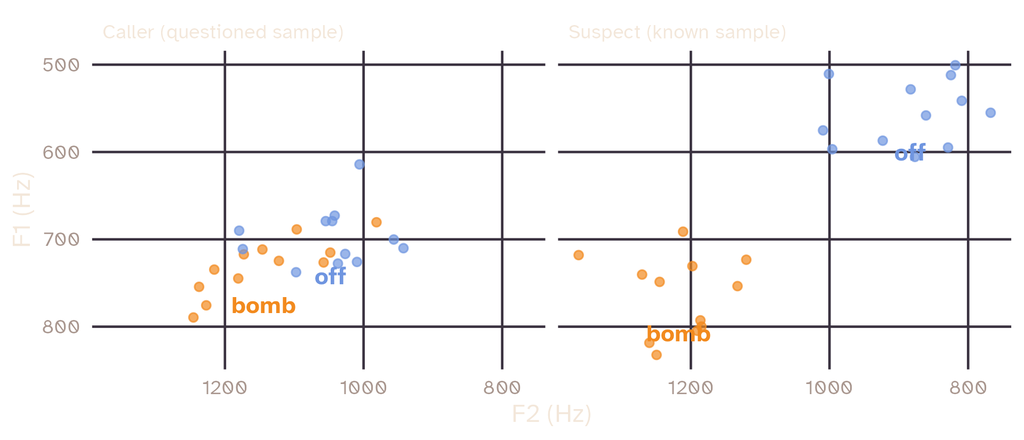

Simulated values, for illustration: the caller merges the two vowels, the suspect keeps them apart.

## What the case shows

- A questioned sample (who is speaking?) is compared with a known sample (a speaker whose identity we know)
- Speaker comparison is the most common type of case in forensic phonetics (session 4)
- Experts use auditory, acoustic and sometimes automatic methods
- They analyse speech sounds, like the vowels here, and features of the voice such as intonation and voice quality

## Today

A refresher of the phonetics behind the rest of the course, with a forensic focus:

1. How speech is produced: the source-filter model, segments and prosody
2. How speech is measured: waveforms, spectrograms, formants, f0, voice quality and tempo
3. Which features forensic phoneticians actually analyse

This session follows chapter 2 of Leemann et al. (2024).

# Speech production

`Did you know:` male koalas bellow at about 27 Hz on average: about 20 times lower than expected for an animal of 8 kg, and more typical of an elephant. They do it with a second pair of vocal folds, the velar vocal folds, outside the larynx.

*Source: Charlton et al. (2013), Current Biology*

## The source-filter model

- Air pushed up from the lungs sets the vocal folds vibrating at the glottis. This vibration is the source
- The oral and nasal tracts then shape the sound, acting as a filter. Moving the tongue, lips and velum changes their resonances
- The filter works a bit like a stereo equaliser, boosting some frequencies and damping others

With the tongue high and front and the lips spread, the output is [i]; with the tongue low and back, it is [ɑ]. The source can stay the same in both.

## Source, filter, output

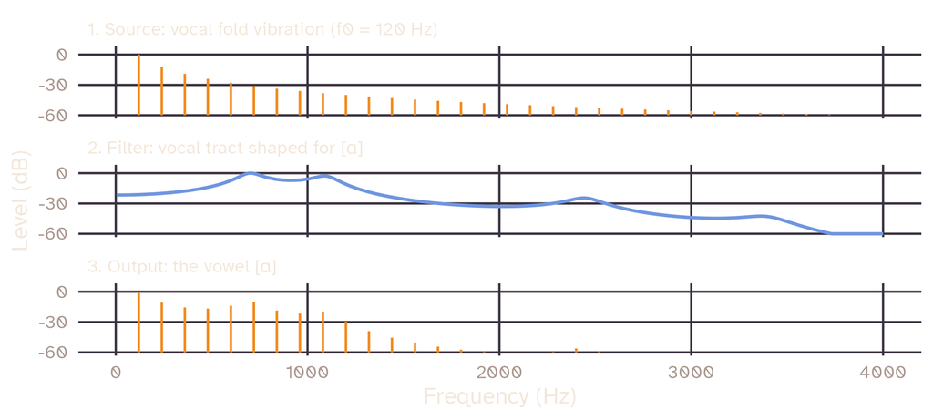

Simulated spectra: the filter’s peaks are the formants.

## Notation

[output not shown]

## Airstreams

Most speech uses an egressive pulmonic airstream, with air pushed out from the lungs. Some sounds use other airstreams: clicks, for example, draw air inwards. In English, clicks are not speech sounds (*tut tut*, or spurring on a horse), but in some African languages, such as Xhosa, they are consonants.

## Segments and prosody

Segments are individual consonants and vowels. Prosody, or suprasegmentals, covers features that stretch over more than one segment, such as stress, intonation, rhythm, tempo, tone and voice quality. Forensic phoneticians analyse both.

## Consonants

Three parameters, often abbreviated VPM:

- Voicing: do the vocal folds vibrate? *fuzzy* (voiced /z/) vs *fussy* (voiceless /s/)
- Place: where is the constriction? From bilabial (lips) to glottal (vocal folds)
- Manner: how is the air obstructed?

/z/ is a voiced alveolar fricative.

## Places of articulation

| Place | Active articulator | Passive articulator | Example |
| --- | --- | --- | --- |
| Bilabial | lower lip | upper lip | [p b m] |
| Labiodental | lower lip | upper teeth | [f v] |
| Dental | tongue tip or blade | upper teeth | [θ ð] |
| Alveolar | tongue tip or blade | alveolar ridge | [t d s z n] |
| Postalveolar | tongue tip or blade | rear of alveolar ridge | [ʃ ʒ] |
| Retroflex | tongue tip | hard palate | [ʈ ɖ] |
| Palatal | tongue front | hard palate | [j ç] |
| Velar | tongue back | soft palate | [k g ŋ] |
| Uvular | tongue back | uvula | [q ʁ] |
| Pharyngeal | tongue root | rear wall of the pharynx | [ħ ʕ] |
| Glottal | vocal folds | (none) | [ʔ h] |

## Manners of articulation

- Obstruents: the airflow is blocked or turbulent
  - plosives (full closure, then release), fricatives (turbulent airflow), affricates (closure, then slow release with friction)
- Sonorants: air escapes easily
  - nasals (velum lowered), approximants (lateral /l/, central /ɹ/), trills, taps and flaps, and all vowels

## Try it

Describe each consonant by voicing, place and manner:

- the first sound of *mother*
- the last sound of *beach*
- the sound written in *sing*
- the sound between the vowels in American English *city*

Voiced bilabial nasal; voiceless postalveolar affricate; voiced velar nasal; voiced alveolar tap.

## Vowels

Three parameters:

- Tongue height: close (high) to open (low)
- Tongue position: front, central, back
- Lip rounding: rounded or unrounded
- [i]: unrounded close front vowel. Add rounding and you get [y], as in German *grün*
- [ɑ]: unrounded open back vowel. Add rounding and you get [ɒ], as in British English LOT
- Diphthongs glide from one quality to another: English *nine*

## Lexical sets

- Wells (1982) named groups of words after a keyword: PRICE stands for all words with the vowel of *price* (*guide*, *might*, *nine*)
- Accents differ in how they pronounce a set, but usually affect all its words in the same way
- Keywords work for every accent, unlike phoneme symbols, which imply the standard accent
- Example: GOOSE has moved forward in young speakers of standard British English: *goose*, *lose*, *youth* all changed
- In some Nigerian and Yorkshire accents, GOOSE is still back, close to [u]

# Prosody

`Did you know:` in koalas, the pitch of a male’s bellow says nothing about his size, but the spacing of its formants does: larger males have lower, more closely spaced formants.

*Source: Charlton et al. (2011), Journal of Experimental Biology*

## Fundamental frequency and pitch

- f0 (“F zero”) is the number of vocal fold vibrations per second, in Hertz, so it is a measurement. Pitch is how high or low we hear a voice, which makes it a percept
- When pitch carries meaning over a phrase, we call it intonation. *The dog chases the cat* with a fall is a statement; with a rise, a question
- In tone languages, pitch also distinguishes words. Thai /kʰa/ with a high tone means “to trade”, with a falling tone “to kill”, with a rising tone “leg”

## Typical f0

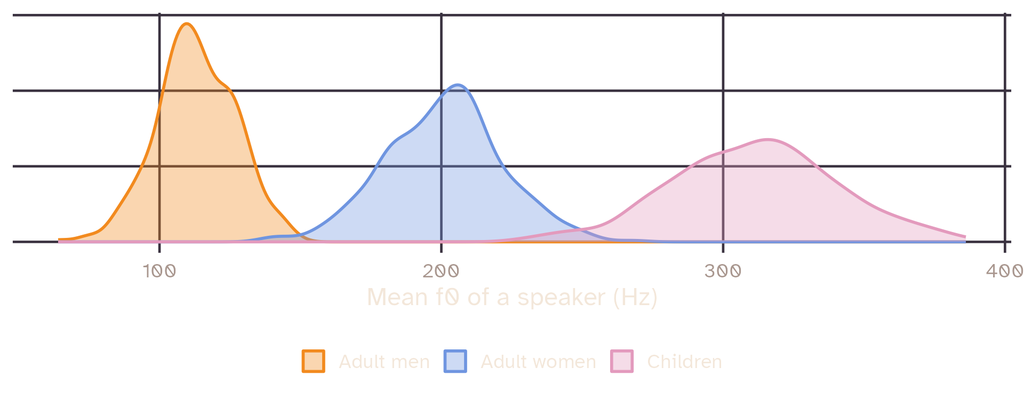

Simulated speakers. Typical values: men 100–125 Hz, women 180–220 Hz, children above 300 Hz. Longer, heavier vocal folds vibrate more slowly.

## Voice quality

The shape and tension of the glottis change the timbre of the voice:

- Modal voice: regular vibration
- Breathy voice: the glottis does not close fully, air escapes
- Whisper: no vibration; turbulent air through a narrow opening
- Creaky voice: slow, irregular vibration of the edges of the folds

Voice quality comes partly from anatomy, but speakers also vary it (attitude), and it changes with health and emotion.

## Prominence and rhythm

- Prominence: stressed syllables stand out, usually by being louder, longer and higher. *IMport* (noun) vs *imPORT* (verb)
- Languages are traditionally classed as stress-timed (stressed syllables at roughly regular intervals, as in English) or syllable-timed (syllables of roughly equal length, as in French). In reality rhythm is a continuum, and no language fits either type perfectly

## Rhythm

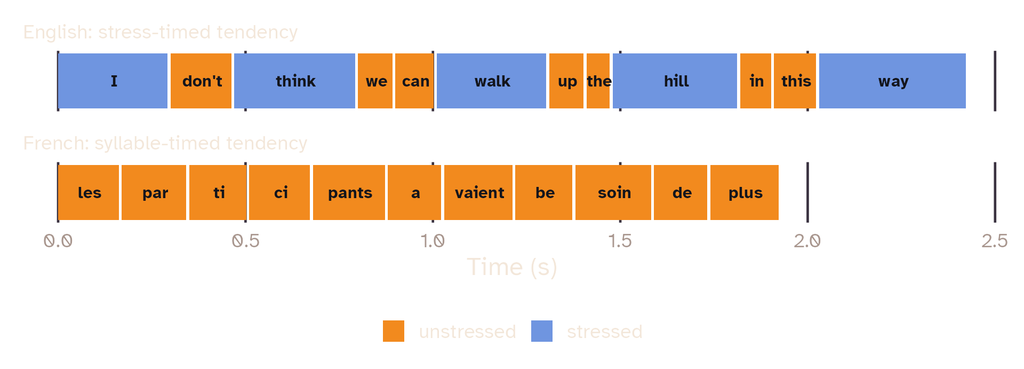

Simulated syllable durations. English shortens unstressed syllables so that stressed ones come at regular intervals.

## Speech tempo

- Articulation rate: syllables per second, without pauses
- Speaking rate: syllables per second, with pauses
- Fast speakers of English produce about 7–8 syllables per second, slow ones about 3–4
- Rates depend on the language’s syllable structure: mostly CV syllables (Japanese) give higher rates than many consonant clusters (Polish)

## Speech tempo

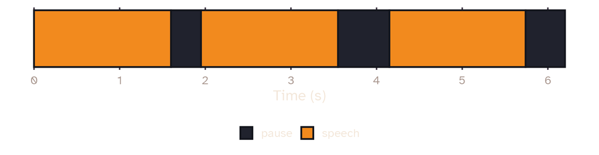

28 syllables in 6.2 s, of which 4.79 s are speech:

- Articulation rate: 28 / 4.79 = 5.8 syllables per second
- Speaking rate: 28 / 6.2 = 4.5 syllables per second

# Acoustic analysis

`Did you know:` male koalas have a permanently descended larynx, the first one found in a marsupial. The formants of their bellows suggest a vocal tract of about 50 cm: nearly the length of the koala’s whole body.

*Source: Charlton et al. (2011), Journal of Experimental Biology*

## Praat

- Free software for speech analysis by Paul Boersma and David Weenink (University of Amsterdam), and the standard tool for students, researchers and forensic experts. *Praat* is Dutch for “talk”
- Measures f0, formants, intensity and voice quality; annotates recordings; draws figures

We will use Praat in the practical sessions. Today is about what its measurements mean.

## The waveform

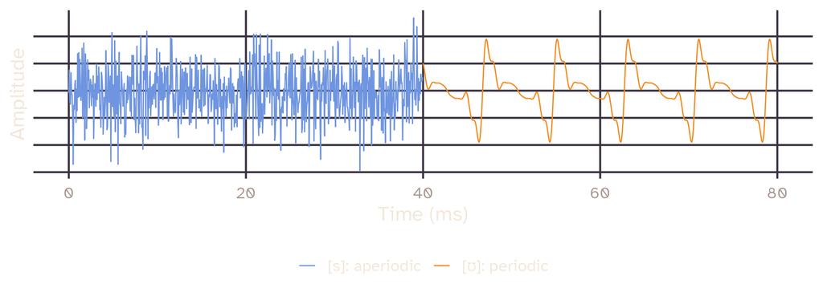

Simulated signal. Voiceless sounds are aperiodic; voiced sounds repeat with every vibration of the vocal folds.

## From waveform to frequencies

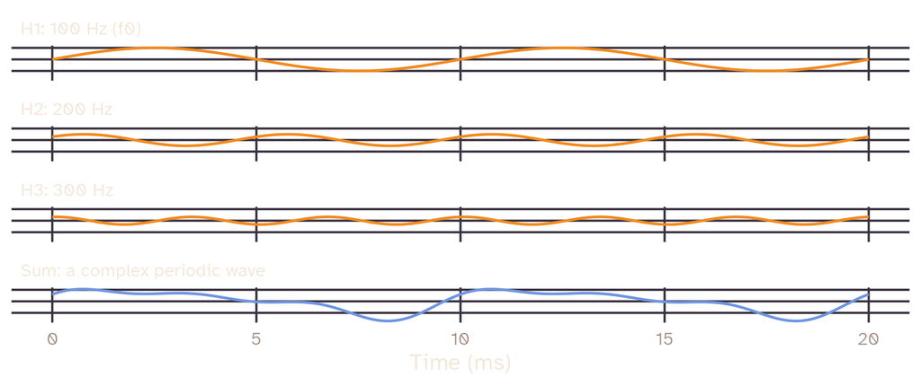

Fourier: every complex periodic wave is a sum of sine waves at whole multiples of f0, the harmonics.

## The spectrogram

- Time on the x-axis, frequency on the y-axis, intensity as darkness
- Each vertical striation is one opening and closing of the glottis (a glottal pulse)
- The vocal tract keeps changing shape, so the pattern of energy keeps changing: a running record of the filter

Try a live spectrogram of your own voice: search for “Chrome Music Lab spectrogram”.

## Consonants in the spectrogram

| Manner | What you see |
| --- | --- |
| Plosive | silence (closure), then a short burst (release) |
| Fricative | aperiodic noise; voiced fricatives add periodic striations |
| Affricate | closure, a weak burst, then frication noise |
| Nasal | weaker energy, broad and less clear formants |
| Approximant | vowel-like formants |
| Tap, trill | one or several very short interruptions |

## Resonance and formants

- Tap a wine glass: its sound depends on its shape and how much air it holds. The vocal tract works the same way
- Formants: the resonances of the vocal tract, dark horizontal bands in a spectrogram
- F1 goes down as the vowel gets closer: close [i] low F1, open [a] high F1
- F2 goes up as the vowel gets fronter: front [i] high F2, back [u] low F2
- F3 reflects lip rounding; F4 and above often carry speaker-specific information

## Bigger tract, lower formants

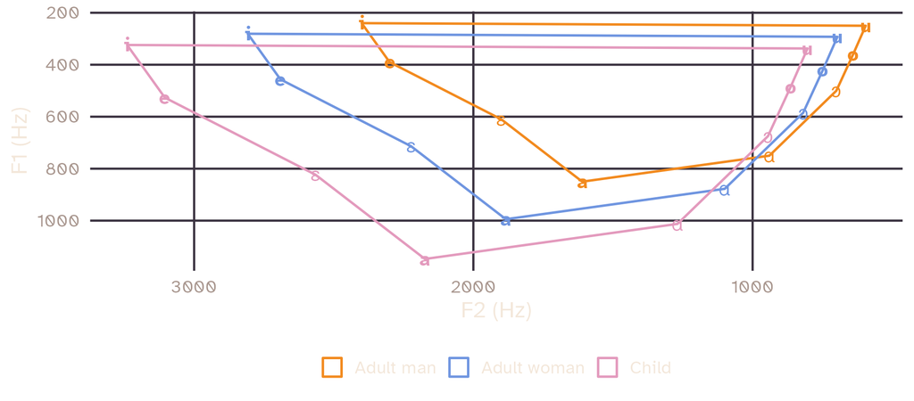

Approximate cardinal vowel formants for an adult man (Catford, 1988), scaled up for illustration. The vowel space keeps its shape but moves up in frequency.

## Measuring f0

- Praat’s voice report gives the average f0 (mean, median, mode), its standard deviation and its range for a selected stretch of speech
- But every f0 value is an estimate: the algorithm can be wrong, especially with noise, unusual voice qualities or poor recordings

## When the tracker gets it wrong

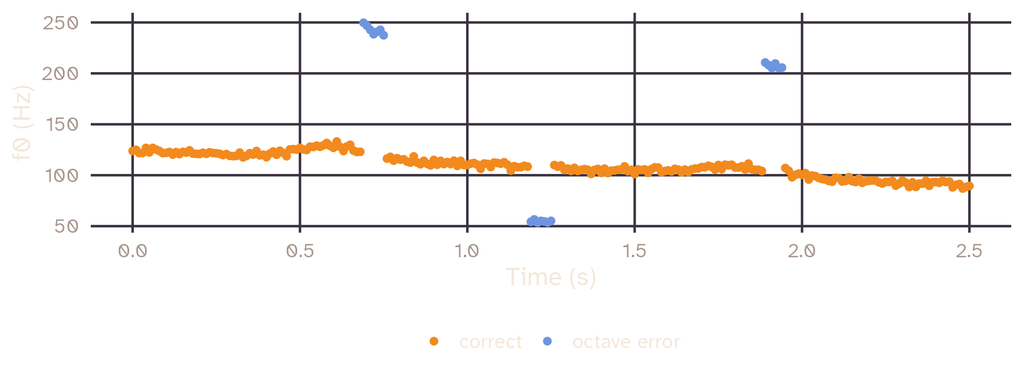

Simulated f0 track of an adult man. Mean with errors: 114 Hz; without: 109 Hz. Median with errors: 109 Hz.

## Check the numbers

- An adult man speaking normally should give f0 values around 100–130 Hz
- Values around 200 Hz could be real (a very high register, or falsetto), or the tracker doubling the true value
- Halved values work the other way
- Always look at the track, and listen, before trusting a summary statistic

## Discussion

In a bomb threat call, the caller’s mean f0 comes out at 190 Hz. The suspect, interviewed calmly at the police station, has a mean of 110 Hz. The defence argues that the caller must be someone else.

- What could explain the gap without a second speaker?
- What would you look at, and listen to, before taking either side?

## Measuring voice quality

- Jitter measures how much the duration of one vibration cycle varies from the next. In healthy young adults it is about 0.5–1%
- Shimmer is the same idea for amplitude
- The harmonics-to-noise ratio (HNR), in dB, falls as a voice gets noisier, hoarser or breathier. Values under 7 dB usually indicate a vocal pathology
- H1–H2, the difference between the first two harmonics, is used as a measure of breathiness and creakiness

## Jitter

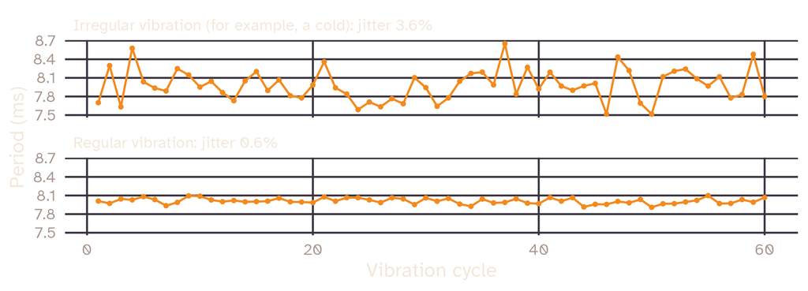

Simulated cycle durations of a voice at 125 Hz (8 ms per cycle).

## Measuring rhythm and tempo

- For prominence, compare the f0, duration and intensity of syllables (*IMport* vs *imPORT*)
- Rhythm measures compare how variable different intervals are: between stressed syllables, between all syllables, or between vowels and consonants
- Tempo is simpler: count the syllables and divide by the duration

Counting syllables is not trivial: *library* has three syllables in careful speech but often two in fast speech. It is usually easier to count the syllables a word would have in careful speech.

# Forensic practice

`Did you know:` every male koala’s bellow is individually distinctive, and playback experiments suggest that koalas can tell males apart by their bellows.

*Source: Charlton et al. (2011), PLoS ONE*

## What experts analyse

Surveys of forensic phoneticians worldwide (Gold & French, 2011, 2019):

- Almost everyone measures vowel formants: F2 most often, then F1 and F3, usually at the vowel midpoint
- Most also analyse consonants, especially fricatives and plosives
- Everyone measures f0, and about 85% analyse intonation
- Most assess voice quality, largely by ear
- Most measure tempo (usually articulation rate); about three quarters look at rhythm
- Non-phonetic features come up too: discourse markers, turn-taking, filled pauses, clicks, breathing, throat clearing, laughter

## Why F1 comes second

Landline telephones pass only about 350 to 3,400 Hz. This tends to raise F1 estimates, especially in close vowels with low F1. We come back to recording quality in session 4.

## Which features identify a speaker best?

Experts’ answers, most often named first:

1. Voice quality
2. Dialect and accent
3. Vowel formants
4. Speech tempo, f0, rhythm, lexical and grammatical choices, fluency

Many experts added that they rely on combinations of features, because no single feature is distinctive enough on its own.

## Exercises

The book’s exercises for this chapter use a short recording of the sentence *When the sunlight strikes raindrops in the air, they act as a prism and form a rainbow*:

- Annotate sounds in Praat
- Measure F1, F2 and F3 at the midpoints of vowels
- Calculate the speaker’s articulation rate

We will do these in the practical sessions.

## Summary

- Speech = a source (vocal fold vibration) shaped by a filter (the vocal tract)
- Consonants: voicing, place, manner. Vowels: height, backness, rounding. Lexical sets work for every accent
- Prosody: f0 and intonation, voice quality, prominence, rhythm, tempo
- F1 tracks vowel height, F2 backness; bigger vocal tracts mean lower formants
- Every measurement is an estimate: check f0 tracks and formant tracks
- Experts look at many features, and at their combination

## References

- Catford, J. C. (1988). *A practical introduction to phonetics*. Oxford University Press.
- Gold, E., & French, P. (2011). International practices in forensic speaker comparison. *International Journal of Speech, Language and the Law*, 18(2), 293–307.
- Gold, E., & French, P. (2019). International practices in forensic speaker comparisons: Second survey. *International Journal of Speech, Language and the Law*, 26(1), 1–20.
- Labov, W. (1988). The judicial testing of linguistic theory. In D. Tannen (Ed.), *Linguistics in context: Connecting observation and understanding* (pp. 159–182). Ablex.
- Leemann, A., Perkins, R., Sullivan Buker, G., & Foulkes, P. (2024). *An Introduction to Forensic Phonetics and Forensic Linguistics*. Routledge. Chapters 2 and 4.
- Wells, J. C. (1982). *Accents of English* (3 vols.). Cambridge University Press.

## Sources of the animal facts

- Charlton, B. D., Ellis, W. A. H., Brumm, J., Nilsson, K., & Fitch, W. T. (2011). Perception of male caller identity in koalas (*Phascolarctos cinereus*): Acoustic analysis and playback experiments. *PLoS ONE*, 6(5), e20329. https://doi.org/10.1371/journal.pone.0020329
- Charlton, B. D., Ellis, W. A. H., McKinnon, A. J., Cowin, G. J., Brumm, J., Nilsson, K., & Fitch, W. T. (2011). Cues to body size in the formant spacing of male koala (*Phascolarctos cinereus*) bellows: Honesty in an exaggerated trait. *Journal of Experimental Biology*, 214(20), 3414–3422. https://doi.org/10.1242/jeb.061358
- Charlton, B. D., Frey, R., McKinnon, A. J., Fritsch, G., Fitch, W. T., & Reby, D. (2013). Koalas use a novel vocal organ to produce unusually low-pitched mating calls. *Current Biology*, 23(23), R1035–R1036. https://doi.org/10.1016/j.cub.2013.10.069
- Henneberg, M., Lambert, K. M., & Leigh, C. M. (1997). Fingerprint homoplasy: Koalas and humans. *Natural Science*, 1, 4.

## Slides and code

[figure not shown]

These slides

mcanzi.de/ws27_fss/02_phonetic_analysis.html

Code and all sessions

github.com/mcanzi/ws27_fss